# Global Health and Economic Indicators 2020

## Life Expectancy in 2020

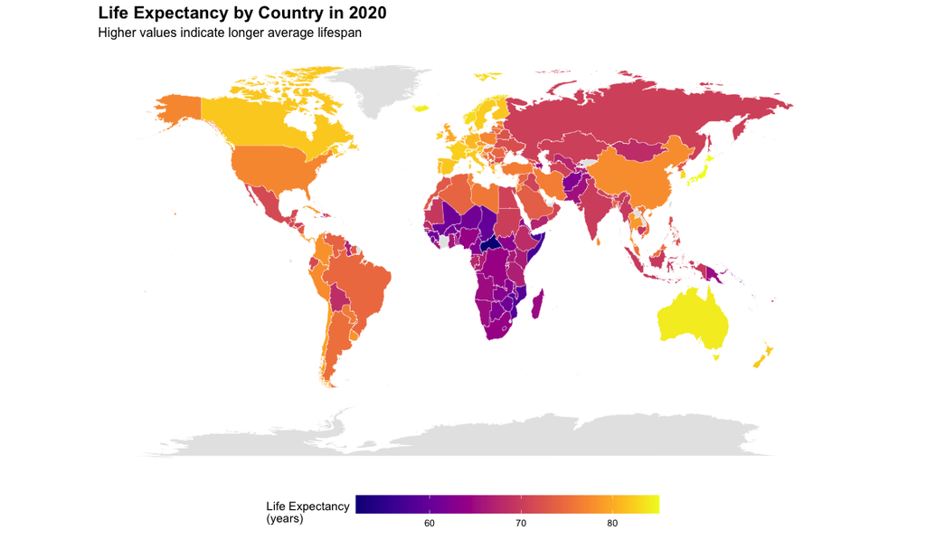

The map shows clear geographical patterns in life expectancy, with developed nations in North America, Europe, and parts of Asia showing higher life expectancies (70-80+ years), while some regions in Africa and parts of Asia show lower values.

## GDP Per Capita in 2020

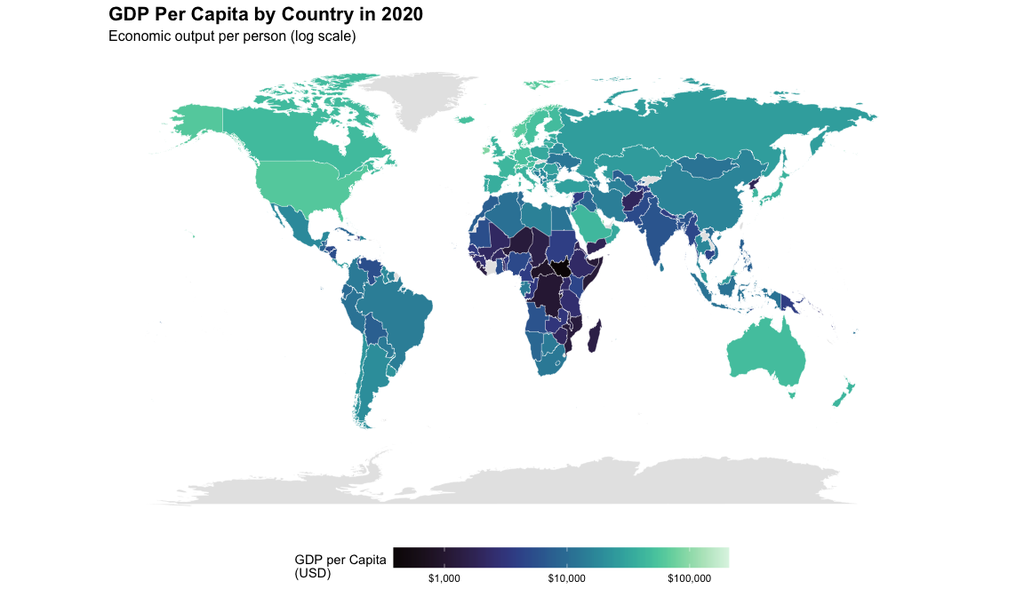

The GDP per capita map reveals substantial economic disparities across the globe. Wealthier nations are concentrated in North America, Western Europe, and parts of Asia and Oceania.

```
##      geo                name           life_expectancy gdp_per_capita
##  Length:193         Length:193         Min.   :51.95   Min.   :   386.7
##  Class :character   Class :character   1st Qu.:66.61   1st Qu.:  4615.5
##  Mode  :character   Mode  :character   Median :72.70   Median : 12407.8
##                                        Mean   :72.06   Mean   : 19942.8
##                                        3rd Qu.:77.12   3rd Qu.: 26953.2
##                                        Max.   :85.07   Max.   :207844.7
##    population         continent
##  Min.   :1.040e+04   Length:193
##  1st Qu.:2.102e+06   Class :character
##  Median :8.921e+06   Mode  :character
##  Mean   :4.065e+07
##  3rd Qu.:2.897e+07
##  Max.   :1.426e+09
```

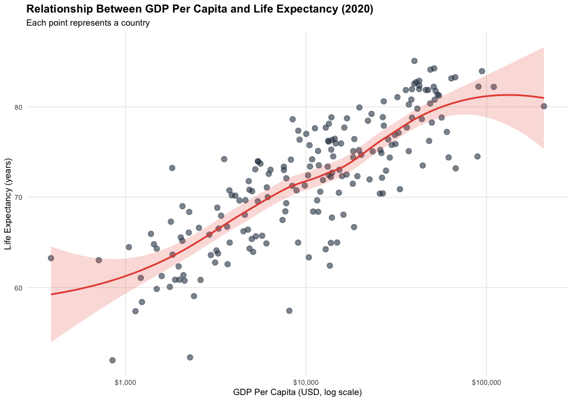